# Master en Big Data. Fundamentos Matemáticos del Análisis de Datos (FMAD).

Tarea 2

Departamento de Matemática Aplicada

Curso 2021-22. Última actualización: 2021-09-24

# Instrucciones preliminares

- Empieza abriendo el proyecto de RStudio correspondiente a tu repositorio personal de la asignatura.
- En todas las tareas tendrás que repetir un proceso como el descrito en la sección *Repite los pasos Creando un fichero Rmarkdown para esta práctica* de la *Práctica00*. Puedes releer la sección *Practicando la entrega de las Tareas* de esa misma práctica para recordar el procedimiento de entrega.

# Ejercicio 1. Simulando variables aleatorias discretas.

**Apartado 1:** La variable aleatoria discreta $X1$ tiene esta tabla de densidad de probabilidad (es la variable que se usa como ejemplo en la Sesión ):
$$\begin{array}{|c|c|c|c|c|c|c|}
\hline
\text{valor de }X1 & 0 & 1 & 2 & 3 \\
\hline
\text{Probabilidad de ese valor }P(X = x_i) & \dfrac{64}{125} &
\dfrac{48}{125}& \dfrac{12}{125} & \dfrac{1}{125}\rule{0mm}{6mm} \\[3mm]
\hline
\end{array}$$
Calcula la media y la varianza teóricas de esta variable.

```r
X1= c(0, 1, 2, 3)
pX1=c(64/125, 48/125, 12/125, 1/125)
media_X1=(X1%*%pX1)
```

```r
mu1=c(media_X1,media_X1,media_X1,media_X1)
varianza=sum((X1-mu1)^2*pX1)
```

**Apartado 2:** Combina `sample` con `replicate` para simular cien mil muestras de tamaño 10 de esta variable $X1$. Estudia la distribución de las medias muestrales como hemos hecho en ejemplos previos, ilustrando con gráficas la distribución de esas medias muestrales. Cambia después el tamaño de la muestra a 30 y repite el análisis.

```r
k = 100000
n = 30
mediasMuestrales1 = replicate (k, {
muestra = sample(X1, n, replace = TRUE,prob = pX1)
mean(muestra)
})
library(tidyverse)
```

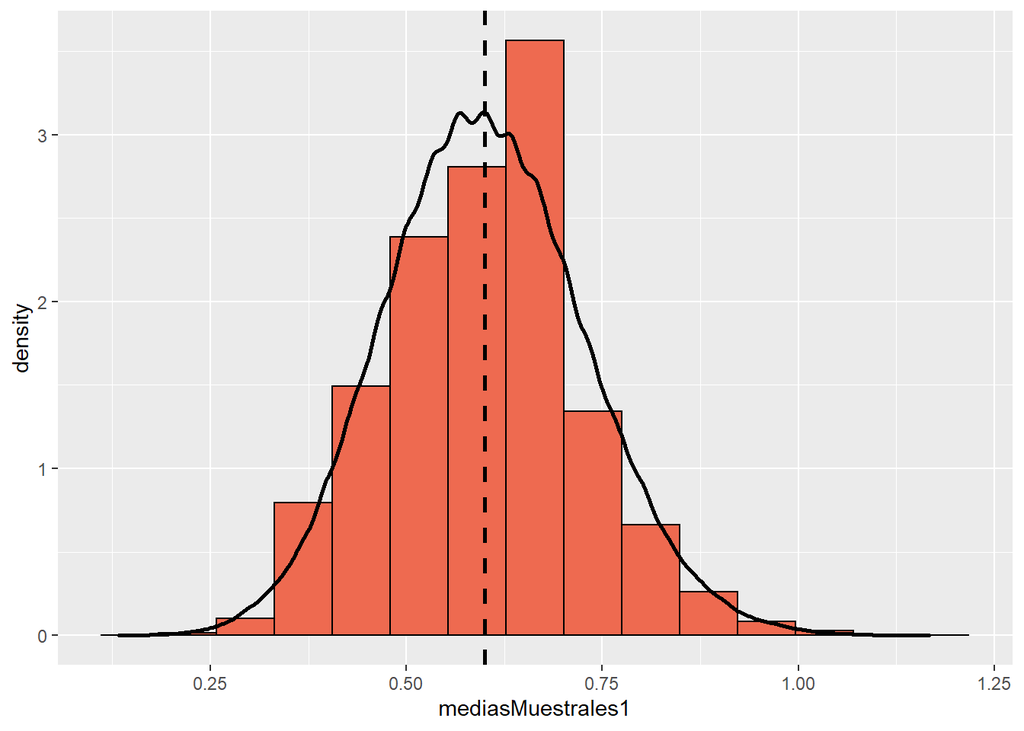

```r
library(ggplot2)
ggplot() +
geom_histogram(aes(x = mediasMuestrales1,y=stat(density)), bins = 15, fill="coral2", color="black") +
geom_vline(xintercept = mean(mediasMuestrales1),
col="black", linetype="dashed", size=1) +
  geom_density(mapping = aes(mediasMuestrales1),color="black",size=1, adjust=1.5)
```

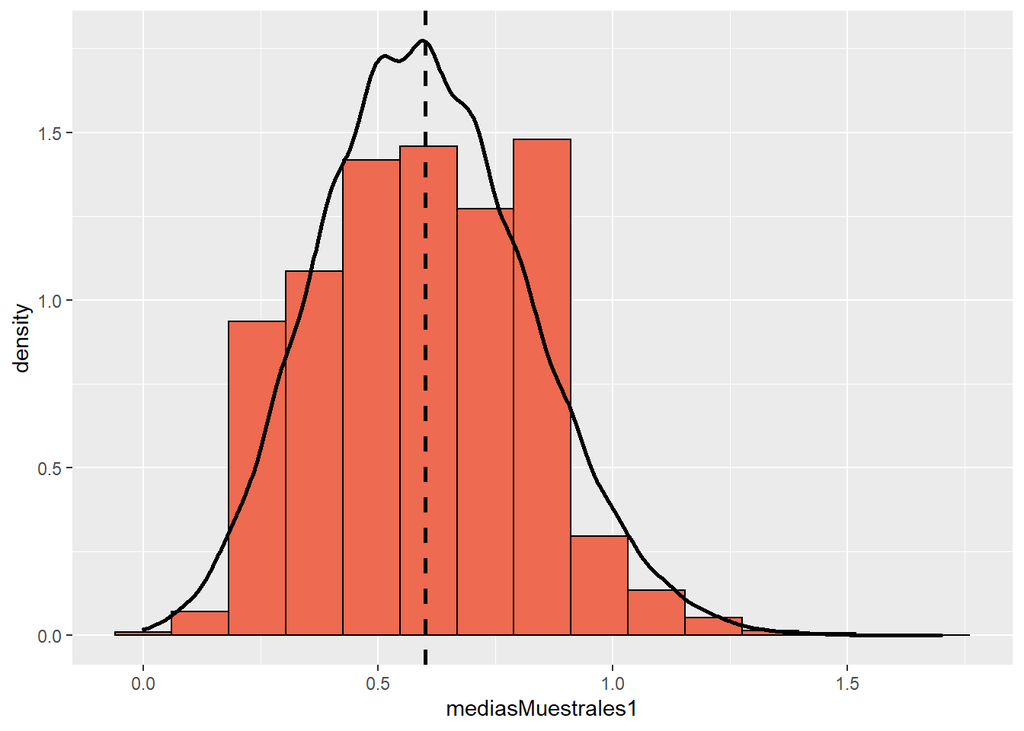

```r
k = 100000
n = 10
mediasMuestrales1 = replicate (k, {
muestra = sample(X1, n, replace = TRUE,prob = pX1)
mean(muestra)
})
library(tidyverse)
library(ggplot2)
ggplot() +
geom_histogram(aes(x = mediasMuestrales1,y=stat(density)), bins = 15, fill="coral2", color="black") +
geom_vline(xintercept = mean(mediasMuestrales1),
col="black", linetype="dashed", size=1) +
  geom_density(mapping = aes(mediasMuestrales1),color="black",size=1, adjust=2.5)
```

**Apartado 3:** La variable aleatoria discreta $X2$ tiene esta tabla de densidad de probabilidad:
$$\begin{array}{|c|c|c|c|c|c|}
\hline
\text{valor de }X2 & 0 & 1 & 2 \\
\hline
\text{Probabilidad de ese valor }P(X = x_i) & \dfrac{1}{2} &
\dfrac{1}{4}& \dfrac{1}{4}\rule{0mm}{6mm} \\[3mm]
\hline
\end{array}$$
Suponemos que $X1$ y $X2$ son independientes. ¿Qué valores puede tomar la suma $X1 + X2$? ¿Cuál es su tabla de probabilidad?

```r
pX2=c(1/2, 1/4, 1/4)
X2=c(0,1,2)
posibles_resultados = c(0, 1, 2, 3, 4, 5)
library(tidyverse)
e= merge(pX1,pX2,by=NULL) %>%
  mutate(probabilidad=x*y) %>%
  select(probabilidad)
g= merge(X1,X2,by=NULL) %>%
  mutate(valores=x+y) %>%
  select(valores)
r =as_tibble(c(e,g))
r %>%
  group_by(valores) %>%
  summarise(prob_final=sum(probabilidad))
```

```
## # A tibble: 6 x 2
##   valores prob_final
##     <dbl>      <dbl>
## 1       0      0.256
## 2       1      0.32
## 3       2      0.272
## 4       3      0.124
## 5       4      0.026
## 6       5      0.002
```

**Apartado 4:** Calcula la media teórica de la suma $X_1 + X_2$. Después usa `sample` y `replicate` para simular cien mil *valores* de esta variable suma. Calcula la media de esos valores. *Advertencia:* no es el mismo tipo de análisis que hemos hecho en el segundo apartado.

```r
media_X2=(X2%*%pX2)
suma_teorica_media=media_X1 + media_X2

z=100000
suma=replicate (z,{sample(X2, 1, replace=TRUE, prob=pX2) + sample(X1, 1, replace=TRUE, prob=pX1)})
suma_media=mean(suma)
z=100000
medX1sum= mean(replicate (z,{sample(X1, 1, replace=TRUE, prob=pX1) }))
medx2sum=mean(replicate (z,{sample(X2, 1, replace=TRUE, prob=pX2) }))
```

# Ejercicio 2. Datos limpios

- Descarga el fichero de este enlace

https://gist.githubusercontent.com/fernandosansegundo/471b4887737cfcec7e9cf28631f2e21e/raw/b3944599d02df494f5903740db5acac9da35bc6f/testResults.csv

```r
getwd()
```

```
## [1] "C:/Users/Anita/Desktop/master/estadisticar/deberes"
```

```r
library(tidyverse)
notas <- read.csv(file ="data/testResults.csv.txt", header = TRUE, sep = ",")
view(notas)
```

- Este fichero contiene las notas de los alumnos de una clase, que hicieron dos tests cada semana durante cinco semanas. La tabla de datos no cumple los principios de *tidy data* que hemos visto en clase. Tu tarea en este ejercicio es explicar por qué no se cumplen y obtener una tabla de datos limpios con la misma información usando *tidyR*.  
  **Indicación:** lee la ayuda de la función `separate` de *tidyR*.

```r
(notas_ordenadas = notas %>%
  pivot_longer(c("week1", "week2", "week3", "week4", "week5"), names_to = "week", values_to = "feedback")) %>%
  separate(gender_age, into = c("gender","age"), sep="_")
```

```
## # A tibble: 1,000 x 7
##    name     id gender age   test_number week  feedback
##    <chr> <int> <chr>  <chr>       <int> <chr>    <int>
##  1 Jacob   108 m      20              1 week1        8
##  2 Jacob   108 m      20              1 week2        5
##  3 Jacob   108 m      20              1 week3        7
##  4 Jacob   108 m      20              1 week4        5
##  5 Jacob   108 m      20              1 week5        6
##  6 Jacob   108 m      20              2 week1        2
##  7 Jacob   108 m      20              2 week2        2
##  8 Jacob   108 m      20              2 week3        4
##  9 Jacob   108 m      20              2 week4        0
## 10 Jacob   108 m      20              2 week5        3
## # ... with 990 more rows
```